# R for Data Science 2e - Chapter 01 - Data Visualization

Author

Farooq Mahmud

**Plot the relationship between flipper length and body mass for the three penguins species in the [palmerpenguins](https://allisonhorst.github.io/palmerpenguins/) dataset.**

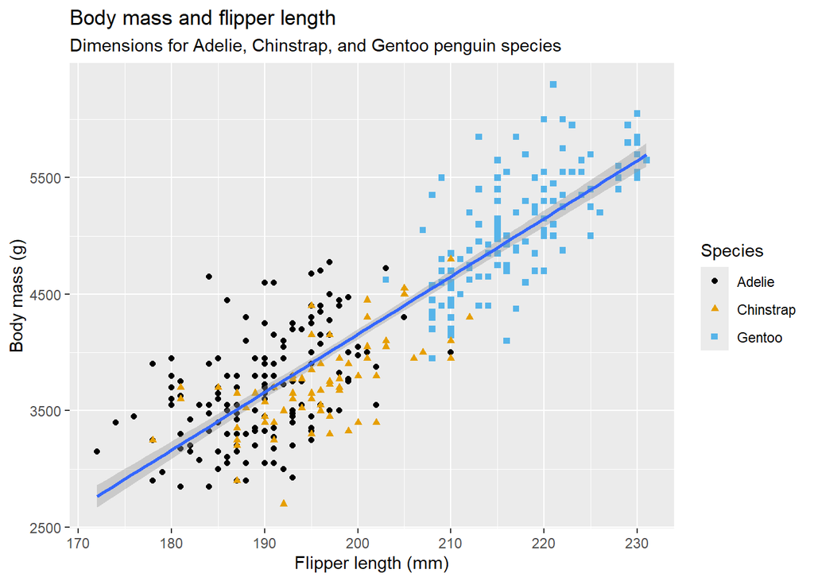

```r
library(tidyverse)
library(palmerpenguins)
library(ggthemes)

penguins_data <- penguins

penguins_data |>
  ggplot(aes(x = flipper_length_mm, y = body_mass_g)) +
  geom_point(mapping = aes(color = species, shape = species)) +
  geom_smooth(method = "lm") +
  labs(
    title = "Body mass and flipper length",
    subtitle = "Dimensions for Adelie, Chinstrap, and Gentoo penguin species",
    x = "Flipper length (mm)", y = "Body mass (g)",
    color = "Species",
    shape = "Species"
  ) +
  scale_color_colorblind()
```

## Exercises

**1. How many rows are in penguins? How many columns?**

```r
glimpse(penguins_data)
```

```
Rows: 344
Columns: 8
$ species           <fct> Adelie, Adelie, Adelie, Adelie, Adelie, Adelie, Adel…
$ island            <fct> Torgersen, Torgersen, Torgersen, Torgersen, Torgerse…
$ bill_length_mm    <dbl> 39.1, 39.5, 40.3, NA, 36.7, 39.3, 38.9, 39.2, 34.1, …
$ bill_depth_mm     <dbl> 18.7, 17.4, 18.0, NA, 19.3, 20.6, 17.8, 19.6, 18.1, …
$ flipper_length_mm <int> 181, 186, 195, NA, 193, 190, 181, 195, 193, 190, 186…
$ body_mass_g       <int> 3750, 3800, 3250, NA, 3450, 3650, 3625, 4675, 3475, …
$ sex               <fct> male, female, female, NA, female, male, female, male…
$ year              <int> 2007, 2007, 2007, 2007, 2007, 2007, 2007, 2007, 2007…
```

**2. What does the bill_depth_mm variable in the penguins data frame describe? Read the help for ?penguins to find out.**

According to the help, bill_depth_mm is a number denoting bill depth in millimeters.

**3.Make a scatterplot of bill_depth_mm versus bill_length_mm. That is, make a scatterplot with bill_depth_mm on the y-axis and bill_length_mm on the x-axis. Describe the relationship between these two variables.**

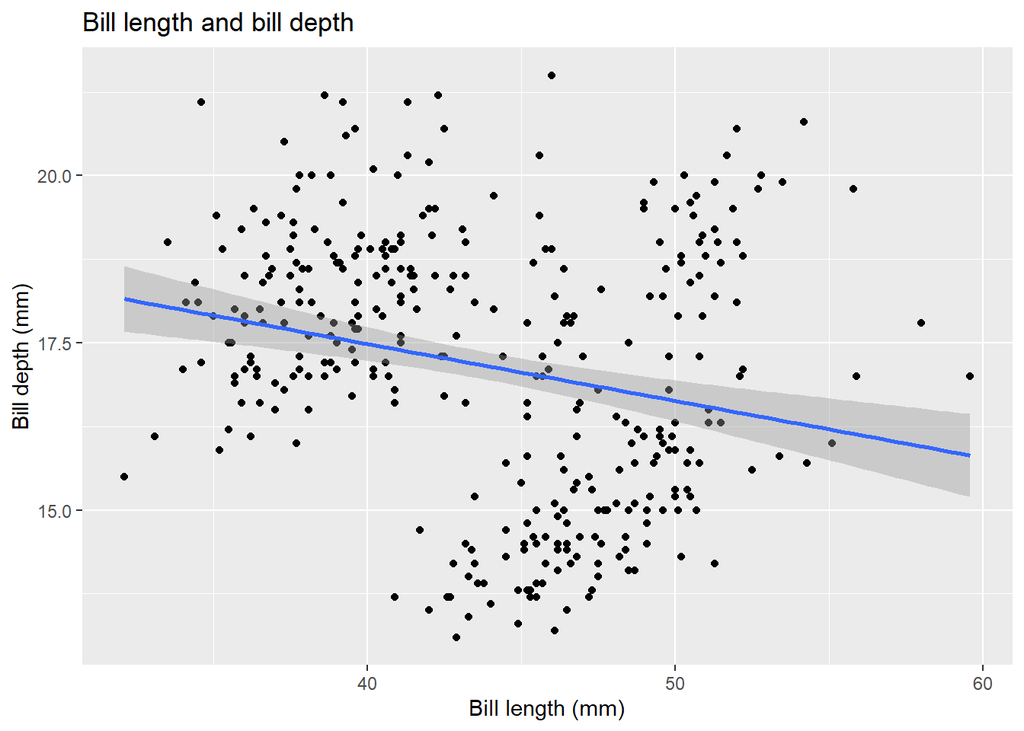

```r
penguins_data |>
  ggplot(aes(x = bill_length_mm, y = bill_depth_mm)) +
  geom_point() +
  labs(
    title = "Bill length and bill depth",
    x = "Bill length (mm)", y = "Bill depth (mm)"
  ) +
  geom_smooth(method = "lm") +
  scale_color_colorblind()
```

```r
cor(penguins_data$bill_length_mm, penguins_data$bill_depth_mm)
```

```
[1] NA
```

**4. What happens if you make a scatterplot of species versus bill_depth_mm? What might be a better choice of geom?**

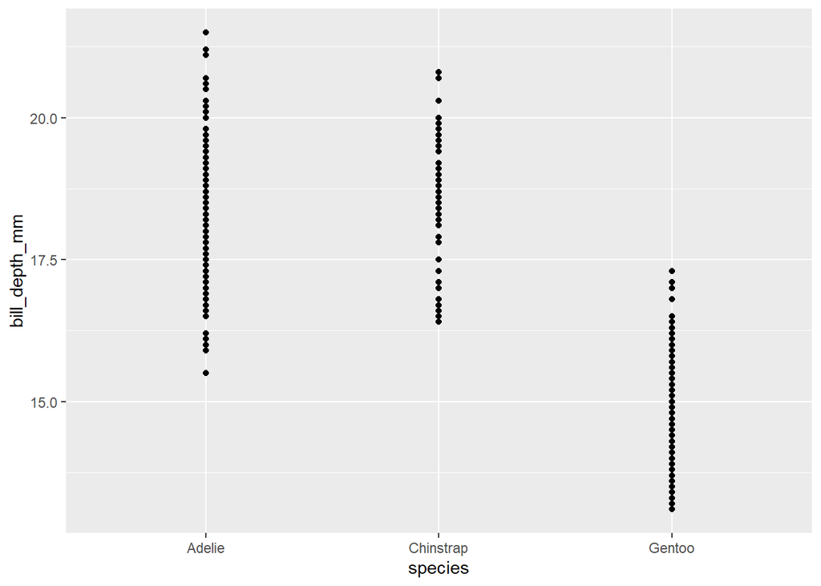

```r
penguins_data |>
  ggplot(aes(x = species, y = bill_depth_mm)) +
  geom_point()
```

`geom_point()` shows a plot with three “lines”, one for each species. A boxplot might be a better visualization.

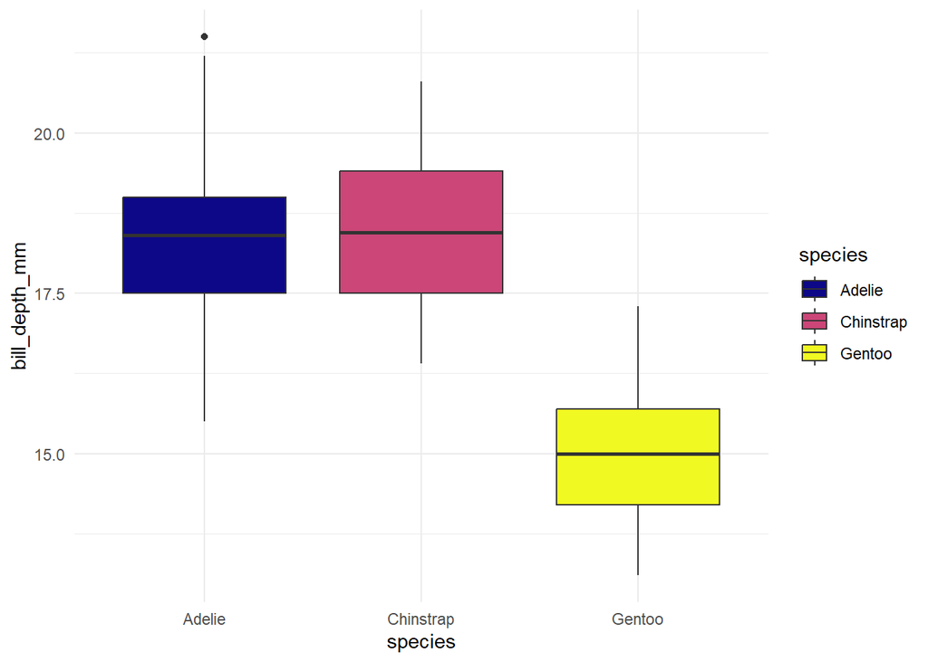

```r
library(viridis)

penguins_data |>
  ggplot(aes(x = species, y = bill_depth_mm, fill = species)) +
  geom_boxplot() +
  scale_fill_viridis_d(option = "C") +
  theme_minimal()
```

**5. Why does the following give an error, and how would you fix it?**

```r
ggplot(data = penguins_data) +
  geom_point()
```

```
Error in `geom_point()`:
! Problem while setting up geom.
ℹ Error occurred in the 1st layer.
Caused by error in `compute_geom_1()`:
! `geom_point()` requires the following missing aesthetics: x and y.
```

This gives an error because an aesthethic must be defined in at least one layer.

**6. What does the `na.rm` argument do in `geom_point()`? What is the default value of the argument? Create a scatterplot where you successfully use this argument set to `TRUE`.

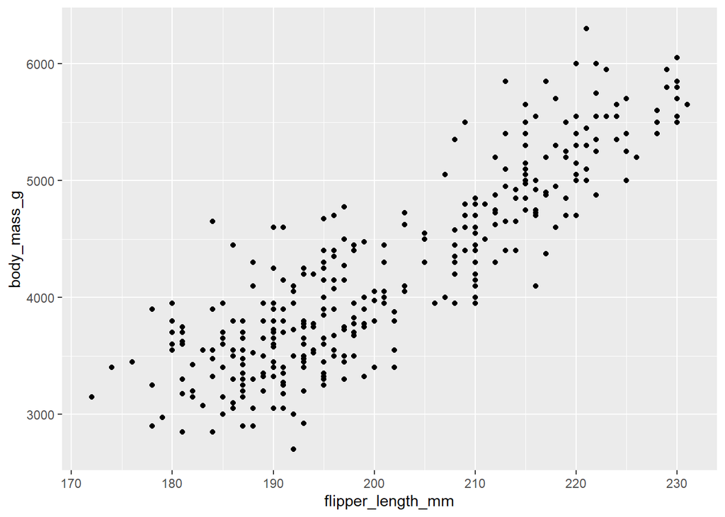

```r
penguins_data2 <- penguins

penguins_data2 |>
  ggplot(mapping = aes(x = flipper_length_mm, y = body_mass_g)) +
  geom_point(na.rm = TRUE)
```

`na.rm` when set to `TRUE`, remmoves missing values, silently. The default value is `FALSE` which removes missing values with a warning.

**7. Add the following caption to the plot you made in the previous exercise: “Data come from the palmerpenguins package.” Hint: Take a look at the documentation for labs().**

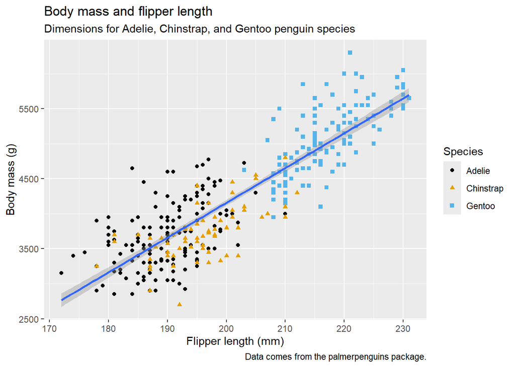

```r
penguins_data |>
  ggplot(aes(x = flipper_length_mm, y = body_mass_g)) +
  geom_point(mapping = aes(color = species, shape = species)) +
  geom_smooth(method = "lm") +
  labs(
    title = "Body mass and flipper length",
    subtitle = "Dimensions for Adelie, Chinstrap, and Gentoo penguin species",
    caption = "Data comes from the palmerpenguins package.",
    x = "Flipper length (mm)", y = "Body mass (g)",
    color = "Species",
    shape = "Species"
  ) +
  scale_color_colorblind()
```

**8. Re-create the following visualization. What aesthetic should bill_depth_mm be mapped to? And should it be mapped at the global level or at the geom level?**

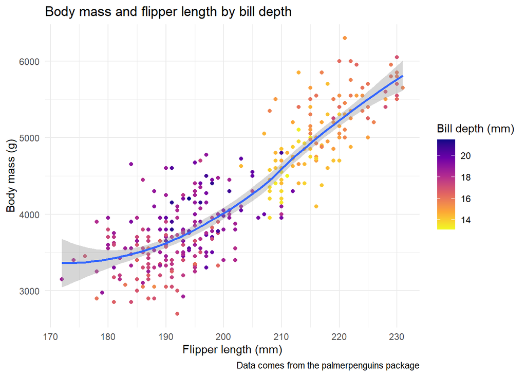

```r
library(viridis)

penguins_data |>
  ggplot(aes(x = flipper_length_mm, y = body_mass_g)) +
  geom_point(mapping = aes(color = bill_depth_mm)) +
  geom_smooth() +
  labs(
    title = "Body mass and flipper length by bill depth",
    caption = "Data comes from the palmerpenguins package",
    x = "Flipper length (mm)", y = "Body mass (g)",
    color = "Bill depth (mm)"
  ) +
  scale_color_viridis_c(option = "C", direction = -1) +
  theme_minimal()
```

Since we want a single fit line, the aesthetic should be mapped to the geom level.